# Assignment 6

## Try to submit as an HTML file

Print your Emory code below

```python
print("2607866")
```

```
2607866
```

Import the "pandas", "matplotlib.pyplot", "numPy" and "statsmodels.formula.api" libraries

```python
import pandas as pd
import numpy as np
import matplotlib.pyplot as plt
import statsmodels.formula.api as smf
```

(a) Functions

- Read the dataset labelled features.csv.
- Create a `lambda` function that checks if horsepower $>$ 100
- Create a new list that shows true if horsepower $>$ 100 and false  
  if horsepower $\leq$ 100.
- Count how many cars have horsewpower $> 100$.

To get full credit use either the apply or the map function  
(see Lectures 7 and 8)

```python
features = pd.read_csv("Data/features.csv")
features['horsepower'] = pd.to_numeric(features['horsepower'], errors='coerce')
fn_speed = lambda horsepower: horsepower > 100
horsepowergreaterthan100 = features["horsepower"].apply(fn_speed)
print(horsepowergreaterthan100)
count = horsepowergreaterthan100.sum()
print(count)
```

```
0       True
1       True
2       True
3       True
4       True
       ...
393    False
394    False
395    False
396    False
397    False
Name: horsepower, Length: 398, dtype: bool
150
```

(b) Subsetting Data

- Read the dataset labelled features.csv.
- Define a global variable called `threshold` that takes the  
  value 3000
- Subset the data to get one dataset with weight $>$ threshold and  
  another with weight $\le$ 3000. Use the `.query()` function.
- Compute the mean acceleration for each of these datasets.

Note: Review how to define a gloabl variable inside `.query()`

```python
threshold = 3000
heavy = features.query("weight > @threshold")
light = features.query("weight <= @threshold")
print(heavy["acceleration"].mean())
print(light["acceleration"].mean())
```

```
14.7
16.202173913043477
```

(c) Regression

In this exercise you are asked to plot acceleration vs. weight and to plot  
the best fit line.

- Run a linear regression between acceleration and weight.
- Extract the intercept and coefficient.
- Using your predicted coefficients, compute the predicted value of acceleration
- Plot a scatter plot with acceleration on the y axis and weight on the x axis.
- On that same figure, plot a line with the predicted values of acceleration

Do not forget to label your axes and title.

```
Intercept    19.606158
weight       -0.001359
dtype: float64
```

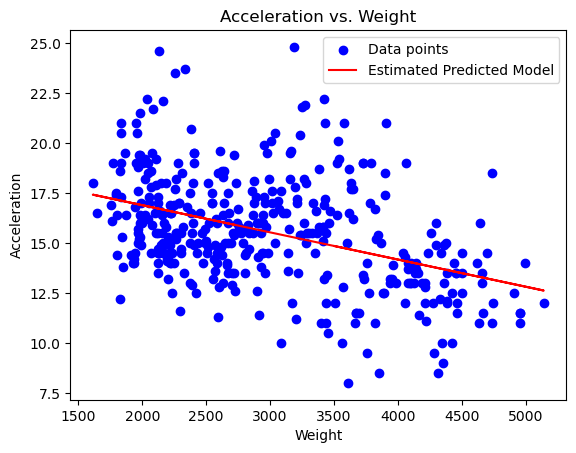

```python
model = smf.ols(formula = 'acceleration ~ weight', data = features)
results = model.fit()
b_list = results.params
print(b_list)
features["p_estimated"] = b_list[0] + b_list[1]  *features["weight"]
plt.scatter(features['weight'], features['acceleration'], color='blue')
plt.plot(features['weight'], features["p_estimated"], color='red')
plt.xlabel('Weight')
plt.ylabel('Acceleration')
plt.title('Acceleration vs. Weight')
plt.legend(labels = ["Data points","Estimated Predicted Model"])
plt.show()
```

(d) Use sorting + ".iloc[]"

- Read the "fifa23_players_basic.csv" dataset
- Use ".sort_values()" to order the "Age" column  
  from youngest to oldest
- Get a subset with the 5 youngest players

```python
fifa = pd.read_csv("Data/fifa23_players_basic.csv")
age_sorted = fifa.sort_values(by="Age", ascending=True)
youngest_players = age_sorted.iloc[:5]
print(youngest_players)
```

```
            Known As        Full Name  Overall  Potential  Value(in Euro)  \
17956     A. Dithmer  Andreas Dithmer       53         76          275000
18014      J. Ardila      José Ardila       53         73          250000
16084       S. Ngoma      Serge Ngoma       58         82          650000
11481      O. Vargas      Obed Vargas       64         81         1500000
17591  A. Madaliński  Alan Madaliński       54         68          210000

      Positions Played Best Position    Nationality  \
17956               GK            GK        Denmark
18014               CM           CAM      Venezuela
16084               RW            RM  United States
11481        CM,CDM,RM           CAM  United States
17591               GK            GK         Poland

                                             Image Link  Age  ...  \
```

[output cut: 35 more lines]

(e) Use queries + global variables

- Read the "fifa23_players_basic.csv" dataset
- Compute the mean of the column "Value(in Euro)"  
  and store it as a variable
- Subset the players whose value is above the mean value  
  using ".query()"

HINT: Remember that there is a special syntax for  
when the column names have spaces (see Lecture 10)  
Reference the column as `` `Value(in Euro)` `` inside .query()

```python
mean = fifa["Value(in Euro)"].mean()
above_mean = fifa.query("`Value(in Euro)` > @mean")
print(above_mean)
```

```
            Known As           Full Name  Overall  Potential  Value(in Euro)  \
0           L. Messi        Lionel Messi       91         91        54000000
1         K. Benzema       Karim Benzema       91         91        64000000
2     R. Lewandowski  Robert Lewandowski       91         91        84000000
3       K. De Bruyne     Kevin De Bruyne       91         91       107500000
4          K. Mbappé       Kylian Mbappé       91         95       190500000
...              ...                 ...      ...        ...             ...
7066       F. Rieder       Fabian Rieder       68         83         2900000
7071     J. Bakayoko      Johan Bakayoko       68         85         3100000
7090        M. Arezo        Matías Arezo       68         81         2900000
7096       Y. Kallon        Yayah Kallon       68         82         3000000
7168        M. Soulé        Matías Soulé       68         85         3100000

     Positions Played Best Position   Nationality  \
0                  RW           CAM     Argentina
```

[output cut: 77 more lines]